# Understanding Black-Box Models

Linh Tran

```r
library(ISLR)
library(caret)

library(vip)
library(pdp)

library(lime) #Local Interpretable Model-agnostic Explanations
```

Predict a baseball player’s salary on the basis of various statistics associated with performance in the previous year.

```r
data(Hitters)
Hitters <- na.omit(Hitters)
head(Hitters)
```

```
##                   AtBat Hits HmRun Runs RBI Walks Years CAtBat CHits CHmRun
## -Alan Ashby         315   81     7   24  38    39    14   3449   835     69
## -Alvin Davis        479  130    18   66  72    76     3   1624   457     63
## -Andre Dawson       496  141    20   65  78    37    11   5628  1575    225
## -Andres Galarraga   321   87    10   39  42    30     2    396   101     12
## -Alfredo Griffin    594  169     4   74  51    35    11   4408  1133     19
## -Al Newman          185   37     1   23   8    21     2    214    42      1
##                   CRuns CRBI CWalks League Division PutOuts Assists Errors
## -Alan Ashby         321  414    375      N        W     632      43     10
## -Alvin Davis        224  266    263      A        W     880      82     14
## -Andre Dawson       828  838    354      N        E     200      11      3
## -Andres Galarraga    48   46     33      N        E     805      40      4
## -Alfredo Griffin    501  336    194      A        W     282     421     25
## -Al Newman           30    9     24      N        E      76     127      7
##                   Salary NewLeague
## -Alan Ashby        475.0         N
## -Alvin Davis       480.0         A
## -Andre Dawson      500.0         N
## -Andres Galarraga   91.5         N
## -Alfredo Griffin   750.0         A
## -Al Newman          70.0         A
```

```r
dim(Hitters)
```

```
## [1] 263  20
```

```r
set.seed(2021)
trRows <- createDataPartition(Hitters$Salary,
                              p = .75,
                              list = F)

ctrl <- trainControl(method = "cv")

# taken from random forest - presumably this is optimal model
rf.grid <- expand.grid(mtry = 1:6,
                       splitrule = "variance",
                       min.node.size = 1:6)

set.seed(1)
rf.fit <- train(Salary~., Hitters[trRows,],
                method = "ranger",
                tuneGrid = rf.grid,
                trControl = ctrl)
```

# Variable importance

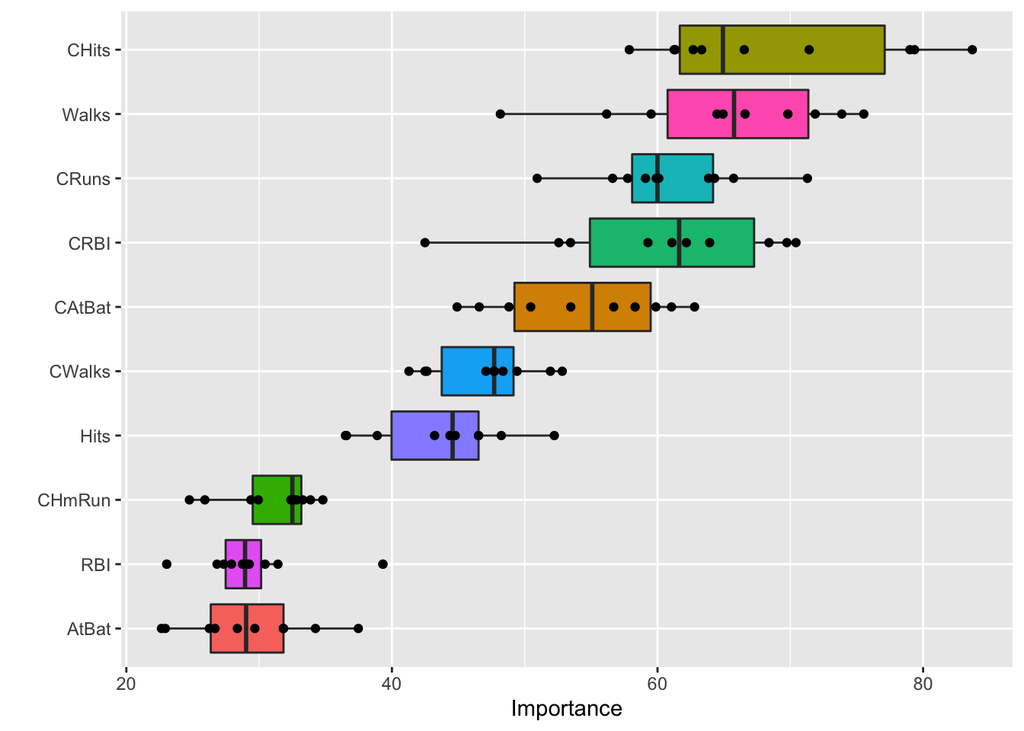

```r
# You can use built-in VIMP in random forests
# The following code is to illustrate vip() in calculating VIMP in a general case
set.seed(1)
vip(rf.fit,
    method = "permute", #can also check `vi_purmute`
    train = Hitters[trRows,],
    target = "Salary",
    metric = "RMSE",
    nsim = 10, #number of simulation
    pred_wrapper = predict,
    geom = "boxplot",
    all_permutations = TRUE,
    mapping = aes_string(fill = "Variable"))
```

```r
    #another argument `num_features` = 10 => plot the top 10 most important variables
```

# Partial dependence plots (PDPs)

After the most relevant variables have been identified, the next step is to attempt to understand how the response variable changes based on these variables.

PDPs plot the change in the average predicted value as specified feature(s) vary over their marginal distribution.

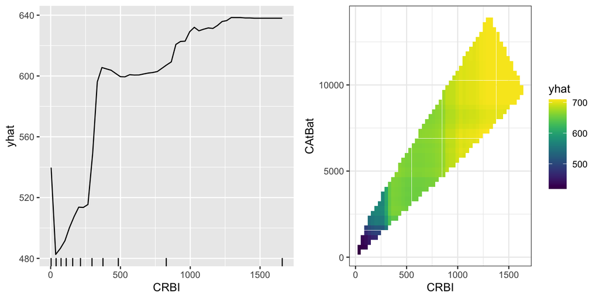

```r
# plot pdp for var CRBI
pdp1.rf <- rf.fit %>%
  partial(pred.var = c("CRBI")) %>%
  autoplot(train = Hitters[trRows,], rug = TRUE)

# `chull` = compact hull | weather you want to restrict the plot within a compact hull region
# distribution of predictors
pdp2.rf <- rf.fit %>%
  partial(pred.var = c("CRBI","CAtBat"), chull = TRUE) %>%
  autoplot(train = Hitters[trRows,], rug = TRUE)

grid.arrange(pdp1.rf, pdp2.rf, nrow = 1)
```

# Individual conditional expectation (ICE) curves

ICE curves are an extension of PDP plots but, rather than plot the average marginal effect on the response variable, we plot the change in the predicted response variable for each observation as we vary each predictor variable.

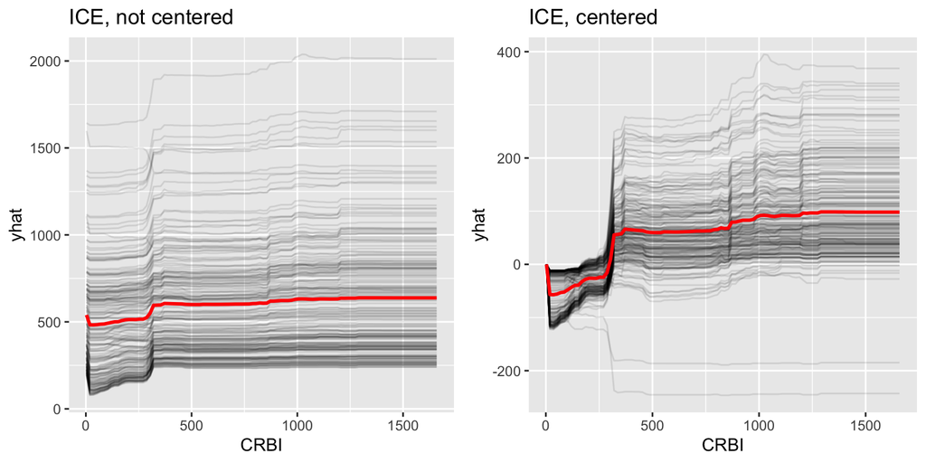

```r
ice1.rf <- rf.fit %>%
  partial(pred.var = "CRBI",
          grid.resolution = 100,
          ice = TRUE) %>%
  autoplot(train = Hitters, alpha = .1) +
  ggtitle("ICE, not centered")

ice2.rf <- rf.fit %>%
  partial(pred.var = "CRBI",
          grid.resolution = 100,
          ice = TRUE) %>%
  autoplot(train = Hitters, alpha = .1,
           center = TRUE) +
  ggtitle("ICE, centered")


grid.arrange(ice1.rf, ice2.rf, nrow = 1)
```

# lime

Once an explainer has been created using the `lime()` function, it can be used to explain the result of the model on new observations. The `explain()` function takes new observation along with the explainer and returns a data.frame with prediction explanations, one observation per row. The function `plot_features()` creates a compact visual representation of the explanations for each case and label combination in an explanation. Each extracted feature is shown with its weight, thus giving the importance of the feature in the label prediction.

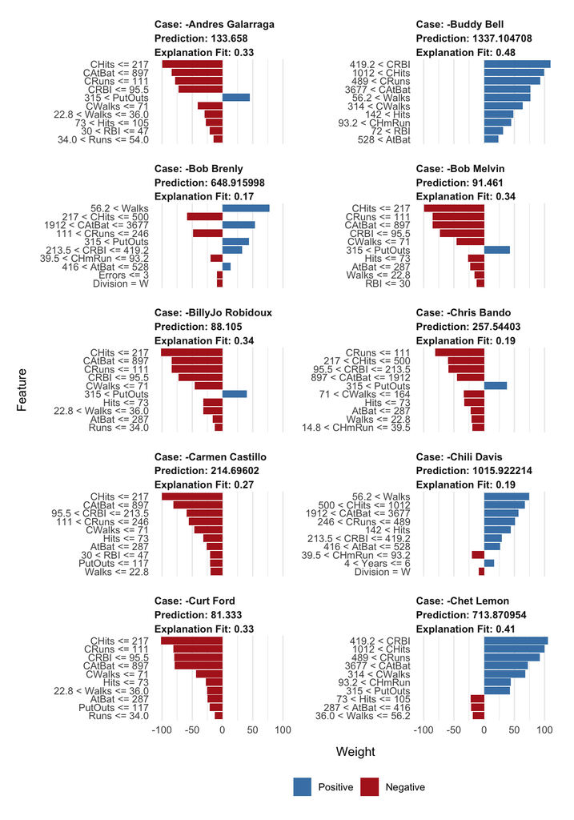

```r
explainer.rf <- lime(Hitters[trRows,-19], rf.fit)

new_obs <- Hitters[-trRows,-19][1:10,]
explanation.obs <- explain(new_obs,
                           explainer.rf,
                           n_features = 10) #simple model will contain 10 features

# Show the impact of 10 variables in making final prediction
plot_features(explanation.obs) #plot coefficients. (explanation fit if low => model is less reliable, R-squared is low). Players who have high salaries tend to have more blue colors (more positive coefficients)
```

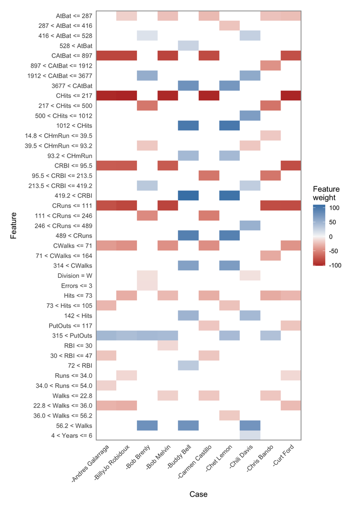

```r
# Give the same info but different styles. Better idea of the different quartiles.
plot_explanations(explanation.obs)
```